# ATD2022_Ficha6_Matlab

### Ficha Prática nº 6 de ATD 2022

Alberto Cardoso ©DEI2021/2022

Objetivo: Pretende-se ilustrar os conceitos de frequência e efetuar a análise de sinais periódicos pela Série de Fourier trigonométrica e complexa.

**Exercício 1.** Pretende-se determinar e representar os coeficientes da Série de Fourier trigonométrica de um sinal periódico, $x(t)$, e apresentar graficamente o sinal original e o aproximado pela Série com um dado número de harmónicos.

**Exercício 1.1** Para isso, escrever um script que efetue as seguintes operações:

**1.1.1.** Pedir o valor do período fundamental, $T_0$, do sinal a analisar.

**1.1.2.** Definir a sequência temporal $t$, durante um período, com, por exemplo, 500 elementos.

**1.1.3.** Obter o sinal $x(t)$ usando um menu que permita escolher uma onda quadrada periódica (use a função square), uma onda periódica em dente de serra (use a função *sawtooth*) ou uma expressão simbólica a introduzir. Representar graficamente $x(t)$.

**1.1.4.** Determinar e representar graficamente os valores dos coeficientes ($Cm$ e $\theta m$) da Série de Fourier trigonométrica com o valor de $m\_max$ da Série de Fourier pedido ao utilizador. Considerar o seguinte algoritmo para o cálculo dos coeficientes:

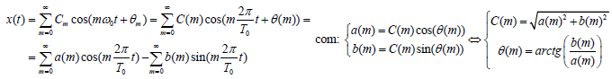

**1.1.5.** Obter e representar graficamente a sobreposição do sinal original e dos sinais aproximados a partir dos coeficientes da Série de Fourier trigonométrica para vários valores limites de $m$ (entre 0 e $m\_max$), pedidos ao utilizador através de um vetor.

**1.1.6.** Obter e representar graficamente a amplitude e a fase dos coeficientes da Série de Fourier complexa $cm$, para $m$ entre $–m\_max$ e $m\_max$, a partir dos coeficientes $Cm$ e $\theta m$.

```matlab
%%file SerieFourier.m

function [Cm,tetam]=SerieFourier(t,x,T0,m_max)
                              % t e x devem ser vetores coluna
   A=zeros(length(t),2*m_max+2);
   for k=0:m_max
      A(:,k+1)=cos(2*pi/T0*t*k);
      A(:,m_max+1+k+1)=-sin(2*pi/T0*t*k);
   end
   coef=pinv(A)*x;
   a=coef(1:m_max+1);
   b=coef(m_max+2:2*m_max+2);
   [nl,nc]=size(a);
   for lin=1:nl,
       for col=1:nc,
           if abs(a(lin,col))<0.001 & abs(b(lin,col))<0.001,
               a(lin,col)=0; b(lin,col)=0;
           end
       end
   end
   Cm=abs(a+b*j);       % <=> Cm=(a.^2+b.^2).^0.5
   tetam=angle(a+b*j);  % <=> tetam=atan(b./a)
end
```

**Exercício 1.2** Aplicar o script de 1.1 para os seguintes sinais:

```matlab
%--- Ex 1.2
%plot inline -w 1200
sympref('HeavisideAtOrigin',1);
```

**Exercício 1.2.1** Onda quadrada periódica de amplitude 1 e período $2\pi s$ (sugestão $m\_max=50$).

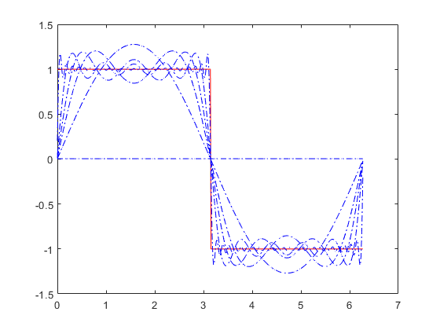

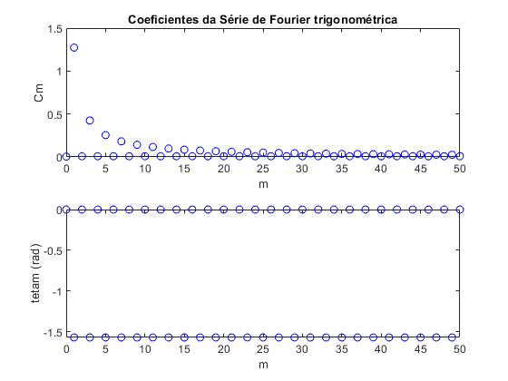

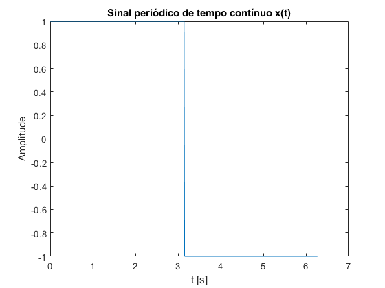

```matlab
%--- Ex 1.2.1
%==========================1.1.1=======================================
%T0= input('Introduza o período fundamental ');
T0 = 2*pi;
%==========================1.1.2=======================================
t=0:T0/500:T0-T0/500;%linspace(0,T0-T0/500,500)
%==========================1.1.3=======================================
%opt=menu('Sinal x(t)','Onda quadrada',...
%'Dente de serra','Expressão');
opt = 1;
switch opt
    case 1,
        x=square(2*pi/T0*t);
        syms t
        xt=heaviside(t)-2*heaviside(t-T0/2);
        t=0:T0/500:T0-T0/500;
        %x=double(subs(xt));
    case 2,
        x=sawtooth(2*pi/T0*t);
        syms t
        xt=(t-T0/2)*2/T0;
        t=0:T0/500:T0-(T0/500);
        %x=double(subs(xt));
    otherwise,
        syms t
        xt=input('x(t)= ');
        t=0:T0/500:T0-T0/500;
        x=double(subs(xt));
end

figure(1)
plot(t,x);
title('Sinal periódico de tempo contínuo x(t)')
xlabel('t [s]')
ylabel('Amplitude');

%m_max=input('Valor de m_max (default=50)=');
m_max=50;
if isempty(m_max)
    m_max=50;
end
%==========================1.1.4=======================================
[Cm,tetam]=SerieFourier(t',x',T0,m_max);
m=0:m_max;

figure(2)
subplot(2,1,1)
plot(m,Cm,'bo');
title('Coeficientes da Série de Fourier trigonométrica')
ylabel('Cm');
xlabel('m');
subplot(2,1,2);
plot(m,tetam,'bo');
ylabel('tetam (rad)');
xlabel('m');

%==========================1.1.5=======================================
figure(3)
plot(t,x,'r');
hold on

%mt=input('Valores limites de m (como vetor)=');
mt=[0 1 3 5 10 50];
if isempty(mt)
    mt=[0 1 3 5 10 50];
end

for k=1:length(mt)
    x1=zeros(size(t));
    for m=0:mt(k)
        x1=x1+Cm(m+1)*cos(m*2*pi/T0*t+tetam(m+1));
    end
    plot(t,x1,'-.b');
end
hold off

%==========================1.1.6=======================================
cm=[flip(Cm(2:end)/2.*exp(-j*tetam(2:end)));...
    Cm(1)*cos(tetam(1));Cm(2:end)/2.*exp(j*tetam(2:end))];
```

**Exercício 1.2.2** Onda periódica em dente de serra de amplitude 1 e período $2\pi s$ (sugestão $m\_max=50$).

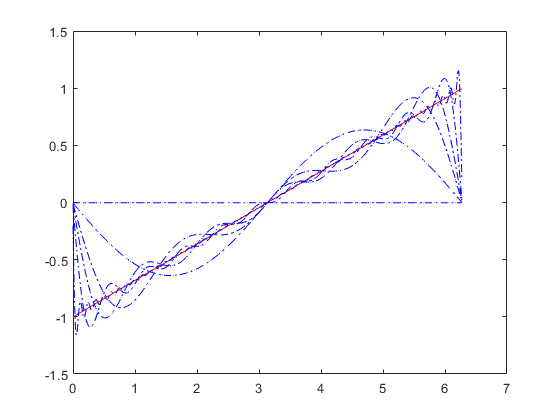

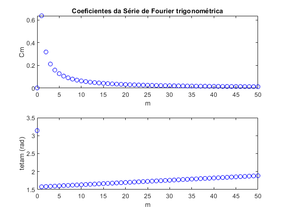

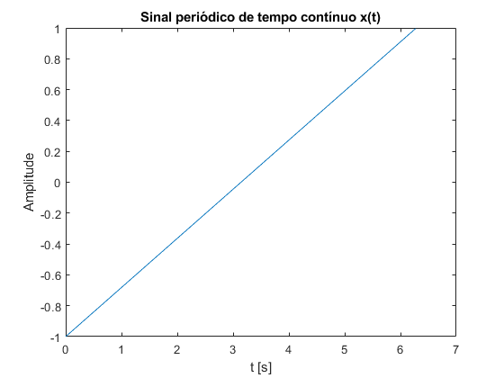

```matlab
%--- Ex 1.2.2
%==========================1.1.1=======================================
%T0= input('Introduza o período fundamental ');
T0 = 2*pi;
%==========================1.1.2=======================================
t=0:T0/500:T0-T0/500;%linspace(0,T0-T0/500,500)
%==========================1.1.3=======================================
%opt=menu('Sinal x(t)','Onda quadrada',...
%'Dente de serra','Expressão');
opt = 2;
switch opt
    case 1,
        x=square(2*pi/T0*t);
        syms t
        xt=heaviside(t)-2*heaviside(t-T0/2);
        t=0:T0/500:T0-T0/500;
        %x=double(subs(xt));
    case 2,
        x=sawtooth(2*pi/T0*t);
        syms t
        xt=(t-T0/2)*2/T0;
        t=0:T0/500:T0-(T0/500);
        %x=double(subs(xt));
    otherwise,
        syms t
        xt=input('x(t)= ');
        t=0:T0/500:T0-T0/500;
        x=double(subs(xt));
end

figure(1)
plot(t,x);
title('Sinal periódico de tempo contínuo x(t)')
xlabel('t [s]')
ylabel('Amplitude');

%m_max=input('Valor de m_max (default=50)=');
m_max=50;
if isempty(m_max)
    m_max=50;
end
%==========================1.1.4=======================================
[Cm,tetam]=SerieFourier(t',x',T0,m_max);
m=0:m_max;

figure(2)
subplot(2,1,1)
plot(m,Cm,'bo');
title('Coeficientes da Série de Fourier trigonométrica')
ylabel('Cm');
xlabel('m');
subplot(2,1,2);
plot(m,tetam,'bo');
ylabel('tetam (rad)');
xlabel('m');

%==========================1.1.5=======================================
figure(3)
plot(t,x,'r');
hold on

%mt=input('Valores limites de m (como vetor)=');
mt=[0 1 3 5 10 50];
if isempty(mt)
    mt=[0 1 3 5 10 50];
end

for k=1:length(mt)
    x1=zeros(size(t));
    for m=0:mt(k)
        x1=x1+Cm(m+1)*cos(m*2*pi/T0*t+tetam(m+1));
    end
    plot(t,x1,'-.b');
end
hold off

%==========================1.1.6=======================================
cm=[flip(Cm(2:end)/2.*exp(-j*tetam(2:end)));...
    Cm(1)*cos(tetam(1));Cm(2:end)/2.*exp(j*tetam(2:end))];
```

**Exercício 1.2.3.** Sinal $x(t) = -2+cos(\pi t) + sin(\pi t+\pi /4$) (sugestão: $m\_max=5$).

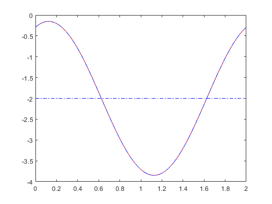

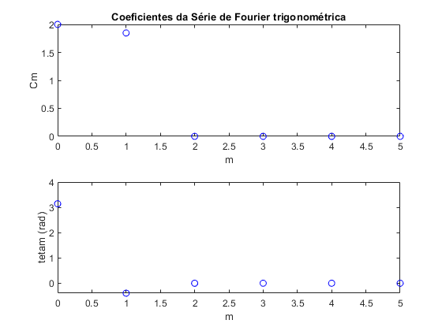

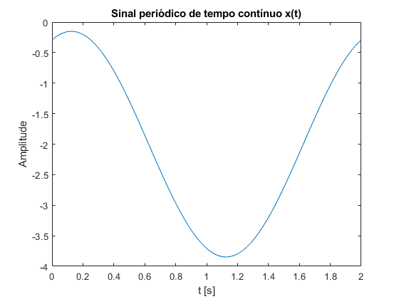

```matlab
%--- Ex 1.2.3
%==========================1.1.1=======================================
%T0= input('Introduza o período fundamental ');
T0 = 2;
%==========================1.1.2=======================================
t=0:T0/500:T0-T0/500;%linspace(0,T0-T0/500,500)
%==========================1.1.3=======================================
%opt=menu('Sinal x(t)','Onda quadrada',...
%'Dente de serra','Expressão');
opt = 3;
switch opt
    case 1,
        x=square(2*pi/T0*t);
        syms t
        xt=heaviside(t)-2*heaviside(t-T0/2);
        t=0:T0/500:T0-T0/500;
        %x=double(subs(xt));
    case 2,
        x=sawtooth(2*pi/T0*t);
        syms t
        xt=(t-T0/2)*2/T0;
        t=0:T0/500:T0-(T0/500);
        %x=double(subs(xt));
    otherwise,
        syms t
        %xt=input('x(t)= ');
        xt=-2+cos(pi*t)+sin(pi*t+pi/4);
        t=0:T0/500:T0-T0/500;
        x=double(subs(xt));
end

figure(1)
plot(t,x);
title('Sinal periódico de tempo contínuo x(t)')
xlabel('t [s]')
ylabel('Amplitude');

%m_max=input('Valor de m_max (default=50)=');
m_max=5;
if isempty(m_max)
    m_max=50;
end
%==========================1.1.4=======================================
[Cm,tetam]=SerieFourier(t',x',T0,m_max);
m=0:m_max;

figure(2)
subplot(2,1,1)
plot(m,Cm,'bo');
title('Coeficientes da Série de Fourier trigonométrica')
ylabel('Cm');
xlabel('m');
subplot(2,1,2);
plot(m,tetam,'bo');
ylabel('tetam (rad)');
xlabel('m');

%==========================1.1.5=======================================
figure(3)
plot(t,x,'r');
hold on

%mt=input('Valores limites de m (como vetor)=');
mt=[0 1 3 5];
if isempty(mt)
    mt=[0 1 3 5 10 50];
end

for k=1:length(mt)
    x1=zeros(size(t));
    for m=0:mt(k)
        x1=x1+Cm(m+1)*cos(m*2*pi/T0*t+tetam(m+1));
    end
    plot(t,x1,'-.b');
end
hold off

%==========================1.1.6=======================================
cm=[flip(Cm(2:end)/2.*exp(-j*tetam(2:end)));...
    Cm(1)*cos(tetam(1));Cm(2:end)/2.*exp(j*tetam(2:end))];
```

**Exercício 1.2.4.** Sinal $𝑥(𝑡)=2sin(5\pi 𝑡)^2+4cos(20\pi 𝑡-\pi/4)sin(45\pi t)$ (sugestão: $𝑚\_𝑚𝑎𝑥=20$).

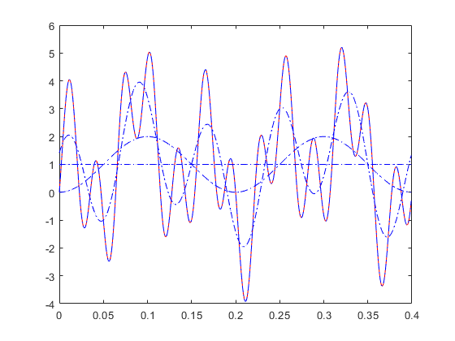

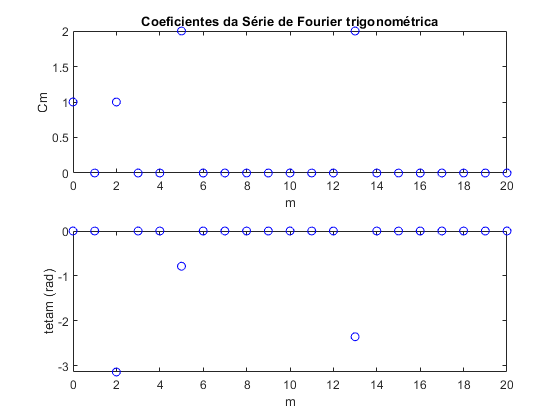

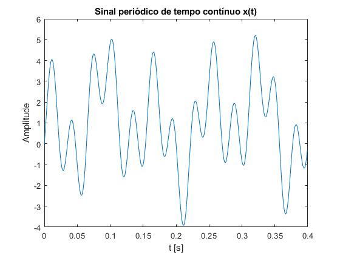

```matlab
%--- Ex 1.2.4
%==========================1.1.1=======================================
%T0= input('Introduza o período fundamental ');
T0 = 0.4;
%==========================1.1.2=======================================
t=0:T0/500:T0-T0/500;%linspace(0,T0-T0/500,500)
%==========================1.1.3=======================================
%opt=menu('Sinal x(t)','Onda quadrada',...
%'Dente de serra','Expressão');
opt = 3;
switch opt
    case 1,
        x=square(2*pi/T0*t);
        syms t
        xt=heaviside(t)-2*heaviside(t-T0/2);
        t=0:T0/500:T0-T0/500;
        %x=double(subs(xt));
    case 2,
        x=sawtooth(2*pi/T0*t);
        syms t
        xt=(t-T0/2)*2/T0;
        t=0:T0/500:T0-(T0/500);
        %x=double(subs(xt));
    otherwise,
        syms t
        %xt=input('x(t)= ');
        xt=2*sin(5*pi*t)^2+4*cos(20*pi*t-pi/4)*sin(45*pi*t);
        t=0:T0/500:T0-T0/500;
        x=double(subs(xt));
end

figure(1)
plot(t,x);
title('Sinal periódico de tempo contínuo x(t)')
xlabel('t [s]')
ylabel('Amplitude');

%m_max=input('Valor de m_max (default=50)=');
m_max=20;
if isempty(m_max)
    m_max=50;
end
%==========================1.1.4=======================================
[Cm,tetam]=SerieFourier(t',x',T0,m_max);
m=0:m_max;

figure(2)
subplot(2,1,1)
plot(m,Cm,'bo');
title('Coeficientes da Série de Fourier trigonométrica')
ylabel('Cm');
xlabel('m');
subplot(2,1,2);
plot(m,tetam,'bo');
ylabel('tetam (rad)');
xlabel('m');

%==========================1.1.5=======================================
figure(3)
plot(t,x,'r');
hold on

%mt=input('Valores limites de m (como vetor)=');
mt=[0 1 3 5 10 20];
if isempty(mt)
    mt=[0 1 3 5 10 50];
end

for k=1:length(mt)
    x1=zeros(size(t));
    for m=0:mt(k)
        x1=x1+Cm(m+1)*cos(m*2*pi/T0*t+tetam(m+1));
    end
    plot(t,x1,'-.b');
end
hold off

%==========================1.1.6=======================================
cm=[flip(Cm(2:end)/2.*exp(-j*tetam(2:end)));...
    Cm(1)*cos(tetam(1));Cm(2:end)/2.*exp(j*tetam(2:end))];
```

**Exercício 1.2.5** Sinal $x(t)=-2+4cos(4\pi t+\pi/3)-2sin(10\pi t)$ (sugestão: $m\_max=10$).

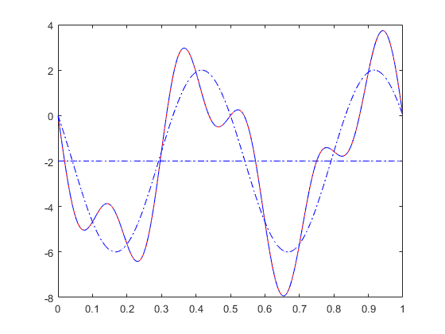

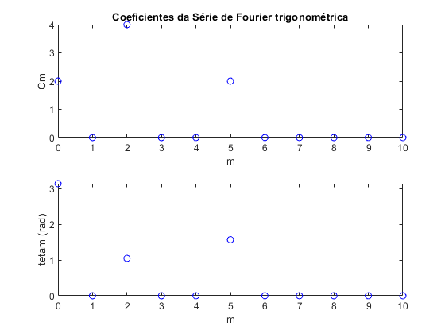

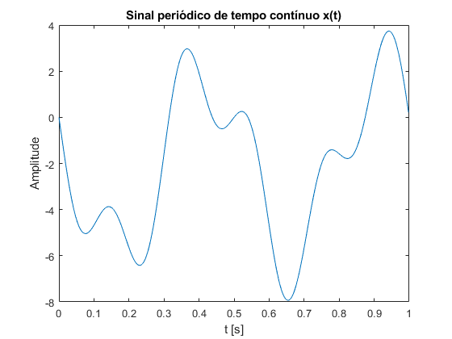

```matlab
%--- Ex 1.2.5
%==========================1.1.1=======================================
%T0= input('Introduza o período fundamental ');
T0 = 1;
%==========================1.1.2=======================================
t=0:T0/500:T0-T0/500;%linspace(0,T0-T0/500,500)
%==========================1.1.3=======================================
%opt=menu('Sinal x(t)','Onda quadrada',...
%'Dente de serra','Expressão');
opt = 3;
switch opt
    case 1,
        x=square(2*pi/T0*t);
        syms t
        xt=heaviside(t)-2*heaviside(t-T0/2);
        t=0:T0/500:T0-T0/500;
        %x=double(subs(xt));
    case 2,
        x=sawtooth(2*pi/T0*t);
        syms t
        xt=(t-T0/2)*2/T0;
        t=0:T0/500:T0-(T0/500);
        %x=double(subs(xt));
    otherwise,
        syms t
        %xt=input('x(t)= ');
        xt=-2+4*cos(4*pi*t+pi/3)-2*sin(10*pi*t);
        t=0:T0/500:T0-T0/500;
        x=double(subs(xt));
end

figure(1)
plot(t,x);
title('Sinal periódico de tempo contínuo x(t)')
xlabel('t [s]')
ylabel('Amplitude');

%m_max=input('Valor de m_max (default=50)=');
m_max=10;
if isempty(m_max)
    m_max=50;
end
%==========================1.1.4=======================================
[Cm,tetam]=SerieFourier(t',x',T0,m_max);
m=0:m_max;

figure(2)
subplot(2,1,1)
plot(m,Cm,'bo');
title('Coeficientes da Série de Fourier trigonométrica')
ylabel('Cm');
xlabel('m');
subplot(2,1,2);
plot(m,tetam,'bo');
ylabel('tetam (rad)');
xlabel('m');

%==========================1.1.5=======================================
figure(3)
plot(t,x,'r');
hold on

%mt=input('Valores limites de m (como vetor)=');
mt=[0 1 3 5 10];
if isempty(mt)
    mt=[0 1 3 5 10 50];
end

for k=1:length(mt)
    x1=zeros(size(t));
    for m=0:mt(k)
        x1=x1+Cm(m+1)*cos(m*2*pi/T0*t+tetam(m+1));
    end
    plot(t,x1,'-.b');
end
hold off

%==========================1.1.6=======================================
cm=[flip(Cm(2:end)/2.*exp(-j*tetam(2:end)));...
    Cm(1)*cos(tetam(1));Cm(2:end)/2.*exp(j*tetam(2:end))];
```

**Exercício 1.3** Determinar analiticamente os coeficientes da Série de Fourier trigonométrica, $Cm$ e $\theta m$, dos sinais indicados em 1.2.3, 1.2.4 e 1.2.5. Comparar com os resultados obtidos em 1.2.

**Exercício 1.4** Determinar analiticamente os coeficientes da Série de Fourier complexa, $cm$, dos sinais indicados em 1.2.3, 1.2.4 e 1.2.5, a partir dos coeficientes da Série de Fourier trigonométrica, $Cm$ e $\theta m$, obtidos em 1.3. Comparar com os resultados obtidos em 1.2.

**Exercício 1.5** Determinar os coeficientes da Série de Fourier complexa, $cm$, dos sinais indicados em 1.2.3, 1.2.4 e 1.2.5, através da expressão $c_m=\frac 1{T_0}\int_{-T_0/2}^{T_0/2} x(t) e^{-jm\omega_0t} dt$ . Comparar com os resultados obtidos em 1.2 e em 1.4.

```
  m  |  cm aproximado  |  cm efetivo

ans =

 -10.0000 + 0.0000i   0.0000 + 0.0000i   0.0000 + 0.0000i
  -9.0000 + 0.0000i   0.0000 + 0.0000i   0.0000 + 0.0000i
  -8.0000 + 0.0000i   0.0000 + 0.0000i   0.0000 + 0.0000i
  -7.0000 + 0.0000i   0.0000 + 0.0000i   0.0000 + 0.0000i
  -6.0000 + 0.0000i   0.0000 + 0.0000i   0.0000 + 0.0000i
  -5.0000 + 0.0000i  -0.0000 - 1.0000i   0.0000 - 1.0000i
  -4.0000 + 0.0000i   0.0000 + 0.0000i   0.0000 + 0.0000i
  -3.0000 + 0.0000i   0.0000 + 0.0000i   0.0000 + 0.0000i
  -2.0000 + 0.0000i   1.0000 - 1.7321i   1.0000 - 1.7321i
  -1.0000 + 0.0000i   0.0000 + 0.0000i   0.0000 + 0.0000i
   0.0000 + 0.0000i  -2.0000 + 0.0000i  -2.0000 + 0.0000i
   1.0000 + 0.0000i   0.0000 + 0.0000i   0.0000 + 0.0000i
   2.0000 + 0.0000i   1.0000 + 1.7321i   1.0000 + 1.7321i
   3.0000 + 0.0000i   0.0000 + 0.0000i   0.0000 + 0.0000i
   4.0000 + 0.0000i   0.0000 + 0.0000i   0.0000 + 0.0000i
   5.0000 + 0.0000i  -0.0000 + 1.0000i   0.0000 + 1.0000i
   6.0000 + 0.0000i   0.0000 + 0.0000i   0.0000 + 0.0000i
   7.0000 + 0.0000i   0.0000 + 0.0000i   0.0000 + 0.0000i
   8.0000 + 0.0000i   0.0000 + 0.0000i   0.0000 + 0.0000i
   9.0000 + 0.0000i   0.0000 + 0.0000i   0.0000 + 0.0000i
  10.0000 + 0.0000i   0.0000 + 0.0000i   0.0000 + 0.0000i
```

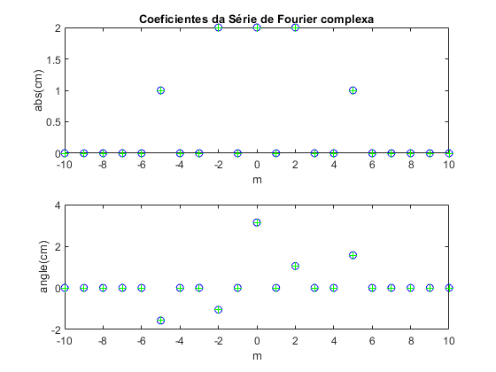

```matlab
%--- Ex 1.5

syms t m
cms=int(xt*exp(-j*m*2*pi*t/T0)/T0,t,0,T0);
cm1=[];
for m=-m_max:m_max
    cm1=[cm1; double(limit(cms,m))];
end

figure(4);
subplot(211);
plot(-m_max:m_max,abs(cm),'bo',-m_max:m_max,abs(cm1),'g+');
title('Coeficientes da Série de Fourier complexa')
ylabel('abs(cm)')
xlabel('m')
subplot(212);
plot(-m_max:m_max,angle(cm),'bo',-m_max:m_max,angle(cm1),'g+');
ylabel('angle(cm)')
xlabel('m')

m=(-m_max:m_max)';
disp('  m  |  cm aproximado  |  cm efetivo')
[m cm cm1]
```

**Exercício 1.6** Determinar os coeficientes da Série de Fourier trigonométrica, $Cm$ e $\theta m$, dos sinais indicados em 1.2.3, 1.2.4 e 1.2.5, a partir dos coeficientes da Série de Fourier complexa, $cm$, obtidos em 1.4. Comparar com os resultados obtidos em 1.2 e em 1.3.

```matlab
%--- Ex 1.6

Cm1=[abs(cm1(m==0)); 2*abs(cm1(m>0))];
tetam1=[angle(cm1(m>=0))];

disp('  m  |  Cm aproximado  |  Cm efetivo')
[m(m>=0) Cm Cm1]

disp('  m  |  tetam aproximado  |  tetam efetivo')
[m(m>=0) tetam tetam1]
```

```
  m  |  Cm aproximado  |  Cm efetivo

ans =

         0    2.0000    2.0000
    1.0000         0         0
    2.0000    4.0000    4.0000
    3.0000         0         0
    4.0000         0         0
    5.0000    2.0000    2.0000
    6.0000         0         0
    7.0000         0         0
    8.0000         0         0
    9.0000         0         0
   10.0000         0         0

  m  |  tetam aproximado  |  tetam efetivo

ans =

         0    3.1416    3.1416
    1.0000         0         0
    2.0000    1.0472    1.0472
    3.0000         0         0
    4.0000         0         0
    5.0000    1.5708    1.5708
    6.0000         0         0
    7.0000         0         0
    8.0000         0         0
    9.0000         0         0
   10.0000         0         0
```